# Rent

# Filtered Data

A researcher on the team has personally lived in these three apartment complexes. As a starting point, and by no means with the intent to provide a final determination, by looking at select data for these complexes perhaps a potential trend worth further research may arise.

Note: the team member aforementioned is male, however for consistency both male and female residents are counted especially given that the parking spaces are provided without distinction related to gender.

```r
# Filtered variables

## New Apartment Names (3)
names_LIST <- c("NORTHPOINT", "SUNDANCE", "WINDSOR MANOR")

#m <- " - MEN"
#w <- " - WOMEN"

## Name (3)
name_1_M <- "NORTHPOINT - MEN"
name_1_W <- "NORTHPOINT - WOMEN"
NORTHPOINT <- c(name_1_M, name_1_W)

name_2_M <- "SUNDANCE - MEN"
name_2_W <- "SUNDANCE - WOMEN"
SUNDANCE <- c(name_2_M, name_2_W)

name_3_M <- "WINDSOR MANOR - MEN"
name_3_W <- "WINDSOR MANOR- WOMEN"
WINDSOR <- c(name_3_M, name_3_W)



## Resident
residents_LIST <- c(
  residents_1 <- sum(Rent$Residents[Rent$Name %in% NORTHPOINT]),
  residents_2 <- sum(Rent$Residents[Rent$Name %in% SUNDANCE]),
  residents_3 <- sum(Rent$Residents[Rent$Name %in% WINDSOR])
)

## Parking Spaces
ParkingSpaces_LIST <- c(
  sum(Rent$ParkingSpaces[Rent$Name == name_1_M]),
  sum(Rent$ParkingSpaces[Rent$Name == name_2_M]),
  sum(Rent$ParkingSpaces[Rent$Name == name_3_M])
)

## Avg of AvgFloorPlanCost
AvgFloorPlanCost_LIST <- c(
  AvgFloorPlanCost_1 <- round(mean(Rent$AvgFloorPlanCost[Rent$Name %in% NORTHPOINT]), digits=0),
  AvgFloorPlanCost_2 <- round(mean(Rent$AvgFloorPlanCost[Rent$Name %in% SUNDANCE]), digits=0),
  AvgFloorPlanCost_3 <- round(mean(Rent$AvgFloorPlanCost[Rent$Name %in% WINDSOR]), digits=0)
)
## Avg MaxFloorPlanCost
AvgMaxFloorPlanCost_LIST <- c(
  MaxFloorPlanCost_1 <- round(mean(Rent$MaxFloorPlanCost[Rent$Name %in% NORTHPOINT]), digits=0),
  MaxFloorPlanCost_2 <- round(mean(Rent$MaxFloorPlanCost[Rent$Name %in% SUNDANCE]), digits=0),
  MaxFloorPlanCost_3 <- round(mean(Rent$MaxFloorPlanCost[Rent$Name %in% WINDSOR]), digits=0)
)


# Construct custom DataFrame
Rent_2 <- data.frame(
  Apartment = names_LIST,
  TotalResidents = residents_LIST,
  ParkingSpaces = ParkingSpaces_LIST,
  AvgFloorPlanCost = AvgFloorPlanCost_LIST,
  MaxFloorPlanCost = AvgMaxFloorPlanCost_LIST
)


# Display table of selected apartments
datatable(Rent_2, options=list(lengthMenu = c(3,2,1)), extensions="Responsive")
```

|  | Apartment | TotalResidents | ParkingSpaces | AvgFloorPlanCost | MaxFloorPlanCost |
| --- | --- | --- | --- | --- | --- |
| 1 | NORTHPOINT | 1024 | 389 | 1621 | 1756 |
| 2 | SUNDANCE | 308 | 100 | 1645 | 1675 |
| 3 | WINDSOR MANOR | 136 | 87 | 1749 | 1749 |

# Graphics

Below are two graphics which aim to illicit potential relationships between the selected variables included in the filtered data.

## Graphic 1

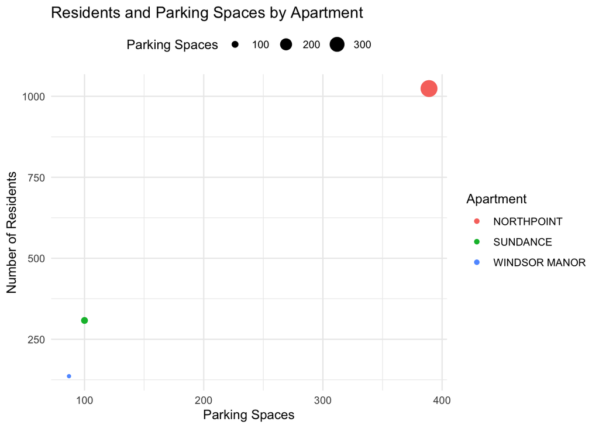

```r
# Use this R-chunk to...
# ...Create an interesting graphic using the Rent data set.


##————————————————————————————————————————————————————————————————————
## Graphic 2:
##————————————————————————————————————————————————————————————————————

# Scatter plot with separate legends
ggplot(Rent_2, aes(x = ParkingSpaces, y = TotalResidents)) +
  geom_point(aes(size = ParkingSpaces, color = Apartment)) +
  theme_minimal() +
  labs(
    title = "Residents and Parking Spaces by Apartment",
    x = "Parking Spaces",
    y = "Number of Residents",
    size = "Parking Spaces",
    color = "Apartment"
  ) +
  guides(
    size = guide_legend(order = 1, position = "top"),               # Parking Spaces legend stays on top
    color = guide_legend(order = 2, position = "right")  # Apartment legend moves to the right
  )
```

From the perspective of a given party certain accommodations or amenities given a select price point seem reasonable such as adequate parking spaces by total residents. However, perhaps despite these accommodations seeming reasonable, circumstances may not allow for their availability. For example, after an apartment complex is constructed and other buildings crowd the area increasing resident or parking capacity becomes limited.

Two concurrent shortages exist in Rexburg: housing and parking. Two things may be of interest to students. First, the correlation between parking availability and total residents at a given apartment complex. Second, possible further correlation with rent pricing.

## Graphic 2

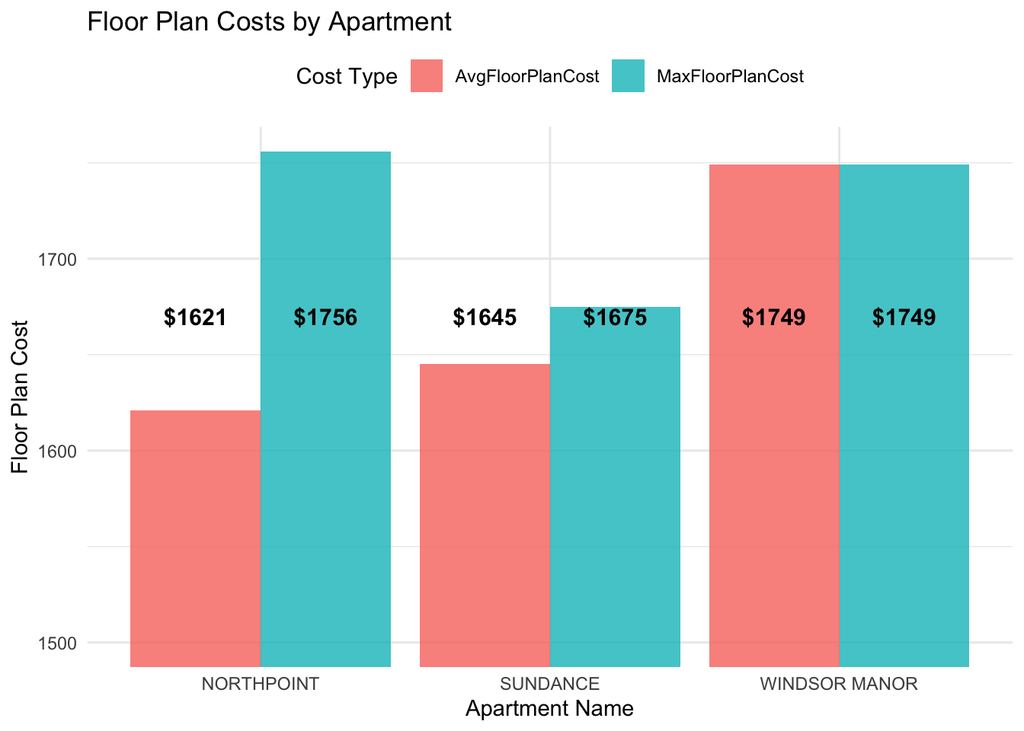

```r
##————————————————————————————————————————————————————————————————————
## Graphic 2:
##————————————————————————————————————————————————————————————————————

### Reshape the data to a long format for AvgFloorPlanCost and MaxFloorPlanCost
Rent_2_long <- Rent_2 %>%
  pivot_longer(
    cols = c(AvgFloorPlanCost, MaxFloorPlanCost),
    names_to = "CostType",
    values_to = "Cost"
  )

### Bar chart for AvgFloorPlanCost and MaxFloorPlanCost by Apartment
ggplot(Rent_2_long, aes(x = Apartment, y = Cost, fill = CostType)) +
  geom_bar(stat = "identity", position = "dodge", alpha = 0.8) +
  geom_text(data = Rent_2_long,
            aes(x = Apartment, y = 1670, label = paste0("$", Cost)),
            position = position_dodge(width = 0.9),
            size = 4, color = "black", fontface = "bold") + # Adds values at y=1650
  theme_minimal() +
  labs(
    title = "Floor Plan Costs by Apartment",
    x = "Apartment Name",
    y = "Floor Plan Cost",
    fill = "Cost Type"
  ) +
  coord_cartesian(ylim = c(1500, NA)) +
  theme(legend.position = "top")
```